# **Decision Tree Project**

For the Data Science and Business Analytics Post-Graduate Program at the University of Texas in Austin

November 16th, 2025

by Jacob Harper Fly  
**The Take Away:** Decision Trees are another supervised learning model used to interpret data that represents classifications in order to determine the optimal strategy for how to respond to some particular case based on historical data. In other words, if I were given a bunch of data on how certain categories describe some objects, and if I knew whether those objects had passed or failed some test, then I could create a decision tree in order to allow someone to describe an object to me in order to have me predict whether it will pass or fail that same test.

## Preface: INN Hotels Project

A significant number of hotel bookings are called-off due to cancellations or no-shows. The typical reasons for cancellations include change of plans, scheduling conflicts, etc. This is often made easier by the option to do so free of charge or preferably at a low cost which is beneficial to hotel guests but it is a less desirable and possibly revenue-diminishing factor for hotels to deal with. Such losses are particularly high on last-minute cancellations.

The new technologies involving online booking channels have dramatically changed customers’ booking possibilities and behavior. This adds a further dimension to the challenge of how hotels handle cancellations, which are no longer limited to traditional booking and guest characteristics.

The cancellation of bookings impact a hotel on various fronts:

- Loss of resources (revenue) when the hotel cannot resell the room.
- Additional costs of distribution channels by increasing commissions or paying for publicity to help sell these rooms.
- Lowering prices last minute, so the hotel can resell a room, resulting in reducing the profit margin.
- Human resources to make arrangements for the guests.

## Objective

The increasing number of cancellations calls for a Machine Learning based solution that can help in predicting which booking is likely to be canceled. INN Hotels Group has a chain of hotels in Portugal, they are facing problems with the high number of booking cancellations and have reached out to your firm for data-driven solutions. You as a data scientist have to analyze the data provided to find which factors have a high influence on booking cancellations, build a predictive model that can predict which booking is going to be canceled in advance, and help in formulating profitable policies for cancellations and refunds.

**Data Dictionary**

- ID: unique identifier of each booking
- Adults #: Number of adults
- Children #: Number of Children
- Weekend Nights #: Number of weekend nights (Saturday or Sunday) the guest stayed or booked to stay at the hotel
- Week Nights #: Number of week nights (Monday to Friday) the guest stayed or booked to stay at the hotel
- The Meal Plan: Type of meal plan booked by the customer:
  - Not Selected – No meal plan selected
  - Meal Plan 1 – Breakfast
  - Meal Plan 2 – Half board (breakfast and one other meal)
  - Meal Plan 3 – Full board (breakfast, lunch, and dinner)
- Parking Space?: Does the customer require a car parking space? (0 - No, 1- Yes)
- The Room Type: Type of room reserved by the customer. The values are ciphered (encoded) by INN Hotels.
- Lead Time #: Number of days between the date of booking and the arrival date
- The Arrival Year: Year of arrival date
- The Arrival Month: Month of arrival date
- The Arrival Day: Date of the month
- The Market Segment: Market segment designation.
- Repeated Guest?: Is the customer a repeated guest? (0 - No, 1- Yes)
- Previous Cancelations?: Number of previous bookings that were canceled by the customer prior to the current booking
- Previous Sincerity?: Number of previous bookings not canceled by the customer prior to the current booking
- Average Price #: Average price per day of the reservation; prices of the rooms are dynamic. (in euros)
- Special Requests #: Total number of special requests made by the customer (e.g. high floor, view from the room, etc)
- The Booking Status: Flag indicating if the booking was canceled or not.

## Importing necessary libraries and data

```python
!pip install pandas==1.5.3 numpy==1.25.2 matplotlib==3.7.1 seaborn==0.13.1 scikit-learn==1.2.2 statsmodels==0.14.1 -q --user
```

[output not shown]

```python
import numpy as np
import pandas as pd
import matplotlib.pyplot as plt
import seaborn as sns
from sklearn.tree import DecisionTreeClassifier
from sklearn.metrics import accuracy_score, precision_score, recall_score, f1_score, confusion_matrix, classification_report, roc_auc_score, roc_curve, precision_recall_curve
from sklearn.model_selection import train_test_split
from sklearn.linear_model import LinearRegression
from sklearn.model_selection import GridSearchCV
from sklearn.metrics import make_scorer
from sklearn.metrics import mean_absolute_error, mean_squared_error, r2_score
import statsmodels.api as sm
from statsmodels.stats.outliers_influence import variance_inflation_factor
from statsmodels.tools.tools import add_constant
from sklearn.tree import export_text
from sklearn.tree import export_graphviz
import graphviz
from google.colab import drive
drive.mount('/content/drive')
```

# My Toolbox

Below are some of the functions that I use when perfoming an analysis on decision trees:

```python
def market_segmenter(data):
  market_segment_counts = data['The Market Segment'].value_counts()
  print('Market Segment Counts:\n', market_segment_counts)
  print(f"\nThe most common market segment is '{market_segment_counts.index[0]}' with {market_segment_counts.iloc[0]} bookings.")
```

```python
def performance_checker(threshold):
  # checking which probabilities are greater than threshold
  pred_temp = lg1.predict(X_train1) > threshold
  # rounding off the above values to get classes
  pred = np.round(pred_temp)

  acc = accuracy_score(y_train, pred)  # to compute Accuracy
  recall = recall_score(y_train, pred)  # to compute Recall
  precision = precision_score(y_train, pred)  # to compute Precision
  f1 = f1_score(y_train, pred)  # to compute F1-score

  # creating a dataframe of metrics
  df_performance = pd.DataFrame(
      {"Accuracy": acc, "Recall": recall, "Precision": precision, "F1": f1,},
      index=[0],
  )
  print("Training performance:")
  return df_performance.head()
```

```python
def heatmapper(threshold):
  y_pred = lg1.predict(X_train1) > threshold
  cm = confusion_matrix(y_train, y_pred)

  plt.figure(figsize=(6, 4))
  sns.heatmap(cm, annot=True, fmt='d', cmap='Blues')
  plt.ylabel("True label")
  plt.xlabel("Predicted label")
  plt.show()
```

## Data Overview

```python
data = pd.read_csv('/content/drive/MyDrive/Data Analytics/Decision Tree/INNHotelsGroup.csv')
data.head()
```

|  | Booking_ID | no_of_adults | no_of_children | no_of_weekend_nights | no_of_week_nights | type_of_meal_plan | required_car_parking_space | room_type_reserved | lead_time | arrival_year | arrival_month | arrival_date | market_segment_type | repeated_guest | no_of_previous_cancellations | no_of_previous_bookings_not_canceled | avg_price_per_room | no_of_special_requests | booking_status |
| --- | --- | --- | --- | --- | --- | --- | --- | --- | --- | --- | --- | --- | --- | --- | --- | --- | --- | --- | --- |
| 0 | INN00001 | 2 | 0 | 1 | 2 | Meal Plan 1 | 0 | Room_Type 1 | 224 | 2017 | 10 | 2 | Offline | 0 | 0 | 0 | 65.00 | 0 | Not_Canceled |
| 1 | INN00002 | 2 | 0 | 2 | 3 | Not Selected | 0 | Room_Type 1 | 5 | 2018 | 11 | 6 | Online | 0 | 0 | 0 | 106.68 | 1 | Not_Canceled |
| 2 | INN00003 | 1 | 0 | 2 | 1 | Meal Plan 1 | 0 | Room_Type 1 | 1 | 2018 | 2 | 28 | Online | 0 | 0 | 0 | 60.00 | 0 | Canceled |
| 3 | INN00004 | 2 | 0 | 0 | 2 | Meal Plan 1 | 0 | Room_Type 1 | 211 | 2018 | 5 | 20 | Online | 0 | 0 | 0 | 100.00 | 0 | Canceled |
| 4 | INN00005 | 2 | 0 | 1 | 1 | Not Selected | 0 | Room_Type 1 | 48 | 2018 | 4 | 11 | Online | 0 | 0 | 0 | 94.50 | 0 | Canceled |

```python
data = data.rename(columns={
    'Booking_ID': 'ID',
    'no_of_adults': 'Adults #',
    'no_of_children': 'Children #',
    'no_of_weekend_nights': 'Weekend Nights #',
    'no_of_week_nights': 'Week Nights #',
    'type_of_meal_plan': 'The Meal Plan',
    'required_car_parking_space': 'Parking Space?',
    'room_type_reserved': 'The Room Type',
    'lead_time': 'Lead Time #',
    'arrival_year': 'The Arrival Year',
    'arrival_month': 'The Arrival Month',
    'arrival_date': 'The Arrival Day',
    'market_segment_type': 'The Market Segment',
    'repeated_guest': 'Repeated Guest?',
    'no_of_previous_cancellations': 'Previous Cancellations #',
    'no_of_previous_bookings_not_canceled': 'Previous Sincerity #',
    'avg_price_per_room': 'Average Price #',
    'no_of_special_requests': 'Special Requests #',
    'booking_status': 'The Booking Status'
})
print(data.columns)
```

```
Index(['ID', 'Adults #', 'Children #', 'Weekend Nights #', 'Week Nights #',
       'The Meal Plan', 'Parking Space?', 'The Room Type', 'Lead Time #',
       'The Arrival Year', 'The Arrival Month', 'The Arrival Day',
       'The Market Segment', 'Repeated Guest?', 'Previous Cancellations #',
       'Previous Sincerity #', 'Average Price #', 'Special Requests #',
       'The Booking Status'],
      dtype='object')
```

```python
data.head()
```

|  | ID | Adults # | Children # | Weekend Nights # | Week Nights # | The Meal Plan | Parking Space? | The Room Type | Lead Time # | The Arrival Year | The Arrival Month | The Arrival Day | The Market Segment | Repeated Guest? | Previous Cancellations # | Previous Sincerity # | Average Price # | Special Requests # | The Booking Status |
| --- | --- | --- | --- | --- | --- | --- | --- | --- | --- | --- | --- | --- | --- | --- | --- | --- | --- | --- | --- |
| 0 | INN00001 | 2 | 0 | 1 | 2 | Meal Plan 1 | 0 | Room_Type 1 | 224 | 2017 | 10 | 2 | Offline | 0 | 0 | 0 | 65.00 | 0 | Not_Canceled |
| 1 | INN00002 | 2 | 0 | 2 | 3 | Not Selected | 0 | Room_Type 1 | 5 | 2018 | 11 | 6 | Online | 0 | 0 | 0 | 106.68 | 1 | Not_Canceled |
| 2 | INN00003 | 1 | 0 | 2 | 1 | Meal Plan 1 | 0 | Room_Type 1 | 1 | 2018 | 2 | 28 | Online | 0 | 0 | 0 | 60.00 | 0 | Canceled |
| 3 | INN00004 | 2 | 0 | 0 | 2 | Meal Plan 1 | 0 | Room_Type 1 | 211 | 2018 | 5 | 20 | Online | 0 | 0 | 0 | 100.00 | 0 | Canceled |
| 4 | INN00005 | 2 | 0 | 1 | 1 | Not Selected | 0 | Room_Type 1 | 48 | 2018 | 4 | 11 | Online | 0 | 0 | 0 | 94.50 | 0 | Canceled |

The Booking ID values are strings with no useful interpretation; therefore, I will drop that column.

```python
data = data.drop(['ID'], axis=1)
data.head()
```

|  | Adults # | Children # | Weekend Nights # | Week Nights # | The Meal Plan | Parking Space? | The Room Type | Lead Time # | The Arrival Year | The Arrival Month | The Arrival Day | The Market Segment | Repeated Guest? | Previous Cancellations # | Previous Sincerity # | Average Price # | Special Requests # | The Booking Status |
| --- | --- | --- | --- | --- | --- | --- | --- | --- | --- | --- | --- | --- | --- | --- | --- | --- | --- | --- |
| 0 | 2 | 0 | 1 | 2 | Meal Plan 1 | 0 | Room_Type 1 | 224 | 2017 | 10 | 2 | Offline | 0 | 0 | 0 | 65.00 | 0 | Not_Canceled |
| 1 | 2 | 0 | 2 | 3 | Not Selected | 0 | Room_Type 1 | 5 | 2018 | 11 | 6 | Online | 0 | 0 | 0 | 106.68 | 1 | Not_Canceled |
| 2 | 1 | 0 | 2 | 1 | Meal Plan 1 | 0 | Room_Type 1 | 1 | 2018 | 2 | 28 | Online | 0 | 0 | 0 | 60.00 | 0 | Canceled |
| 3 | 2 | 0 | 0 | 2 | Meal Plan 1 | 0 | Room_Type 1 | 211 | 2018 | 5 | 20 | Online | 0 | 0 | 0 | 100.00 | 0 | Canceled |
| 4 | 2 | 0 | 1 | 1 | Not Selected | 0 | Room_Type 1 | 48 | 2018 | 4 | 11 | Online | 0 | 0 | 0 | 94.50 | 0 | Canceled |

```python
rown, coln = data.shape
print(f'The dataset has {rown} rows and {coln} columns.')
```

```
The dataset has 36275 rows and 18 columns.
```

```python
data.info()
```

```
<class 'pandas.core.frame.DataFrame'>
RangeIndex: 36275 entries, 0 to 36274
Data columns (total 18 columns):
 #   Column                    Non-Null Count  Dtype
---  ------                    --------------  -----
 0   Adults #                  36275 non-null  int64
 1   Children #                36275 non-null  int64
 2   Weekend Nights #          36275 non-null  int64
 3   Week Nights #             36275 non-null  int64
 4   The Meal Plan             36275 non-null  object
 5   Parking Space?            36275 non-null  int64
 6   The Room Type             36275 non-null  object
 7   Lead Time #               36275 non-null  int64
 8   The Arrival Year          36275 non-null  int64
 9   The Arrival Month         36275 non-null  int64
 10  The Arrival Day           36275 non-null  int64
 11  The Market Segment        36275 non-null  object
 12  Repeated Guest?           36275 non-null  int64
 13  Previous Cancellations #  36275 non-null  int64
 14  Previous Sincerity #      36275 non-null  int64
 15  Average Price #           36275 non-null  float64
 16  Special Requests #        36275 non-null  int64
 17  The Booking Status        36275 non-null  object
dtypes: float64(1), int64(13), object(4)
memory usage: 5.0+ MB
```

```python
data.duplicated().sum()
```

```
np.int64(10275)
```

```python
data.describe().T
```

|  | count | mean | std | min | 25% | 50% | 75% | max |
| --- | --- | --- | --- | --- | --- | --- | --- | --- |
| Adults # | 36275.0 | 1.844962 | 0.518715 | 0.0 | 2.0 | 2.00 | 2.0 | 4.0 |
| Children # | 36275.0 | 0.105279 | 0.402648 | 0.0 | 0.0 | 0.00 | 0.0 | 10.0 |
| Weekend Nights # | 36275.0 | 0.810724 | 0.870644 | 0.0 | 0.0 | 1.00 | 2.0 | 7.0 |
| Week Nights # | 36275.0 | 2.204300 | 1.410905 | 0.0 | 1.0 | 2.00 | 3.0 | 17.0 |
| Parking Space? | 36275.0 | 0.030986 | 0.173281 | 0.0 | 0.0 | 0.00 | 0.0 | 1.0 |
| Lead Time # | 36275.0 | 85.232557 | 85.930817 | 0.0 | 17.0 | 57.00 | 126.0 | 443.0 |
| The Arrival Year | 36275.0 | 2017.820427 | 0.383836 | 2017.0 | 2018.0 | 2018.00 | 2018.0 | 2018.0 |
| The Arrival Month | 36275.0 | 7.423653 | 3.069894 | 1.0 | 5.0 | 8.00 | 10.0 | 12.0 |
| The Arrival Day | 36275.0 | 15.596995 | 8.740447 | 1.0 | 8.0 | 16.00 | 23.0 | 31.0 |
| Repeated Guest? | 36275.0 | 0.025637 | 0.158053 | 0.0 | 0.0 | 0.00 | 0.0 | 1.0 |
| Previous Cancellations # | 36275.0 | 0.023349 | 0.368331 | 0.0 | 0.0 | 0.00 | 0.0 | 13.0 |
| Previous Sincerity # | 36275.0 | 0.153411 | 1.754171 | 0.0 | 0.0 | 0.00 | 0.0 | 58.0 |
| Average Price # | 36275.0 | 103.423539 | 35.089424 | 0.0 | 80.3 | 99.45 | 120.0 | 540.0 |
| Special Requests # | 36275.0 | 0.619655 | 0.786236 | 0.0 | 0.0 | 0.00 | 1.0 | 5.0 |

**Observations**

- Only 3% of customers required a parking.
- The average customer booked 85 days in advance.
- Most of the data was from 2018 with less that 25% from 2017.
- Less than 3% of customers were returning guests.
- The average price of a room is 103 euros.

Now, I will create two data sets in order to compare how the canceled booksing compared to those that weren't canceled.

```python
Bad = data[data['The Booking Status'] == 'Canceled'].copy()
Good = data[data['The Booking Status'] == 'Not_Canceled'].copy()
```

## Exploratory Data Analysis (EDA)

**Leading Questions**:

1. What are the busiest months in the hotel?
2. Which market segment do most of the guests come from?
3. Hotel rates are dynamic and change according to demand and customer demographics. What are the differences in room prices in different market segments?
4. What percentage of bookings are canceled?
5. Repeating guests are the guests who stay in the hotel often and are important to brand equity. What percentage of repeating guests cancel?
6. Many guests have special requirements when booking a hotel room. Do these requirements affect booking cancellation?

First, let's check how the number of canceled bookings compares to those which we not canceled across all customers in the dataset.

```
Booking Status Counts:
 The Booking Status
Not_Canceled    24390
Canceled        11885
Name: count, dtype: int64
```

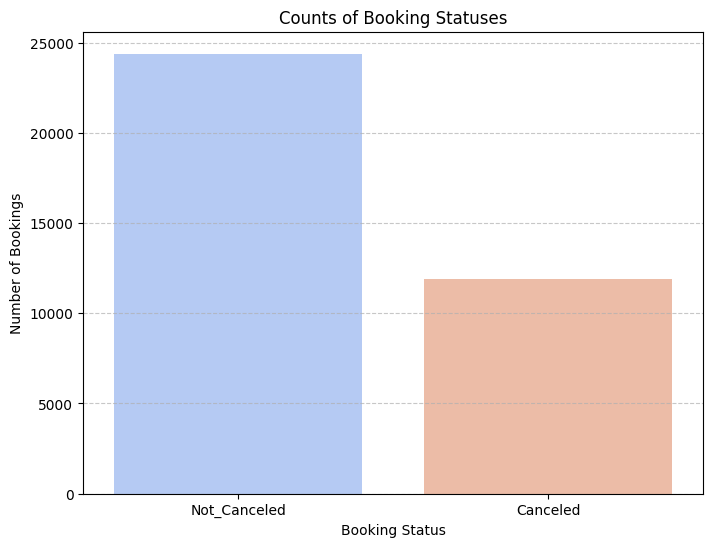

```python
booking_status_counts = data['The Booking Status'].value_counts()

print("Booking Status Counts:\n", booking_status_counts)

plt.figure(figsize=(8, 6))
sns.barplot(x=booking_status_counts.index, y=booking_status_counts.values, palette='coolwarm')
plt.title('Counts of Booking Statuses')
plt.xlabel('Booking Status')
plt.ylabel('Number of Bookings')
plt.grid(axis='y', linestyle='--', alpha=0.7)
plt.show()
```

### Busiest Months

```
Bookings per month:
 The Arrival Month
1     1014
2     1704
3     2358
4     2736
5     2598
6     3203
7     2920
8     3813
9     4611
10    5317
11    2980
12    3021
Name: count, dtype: int64
```

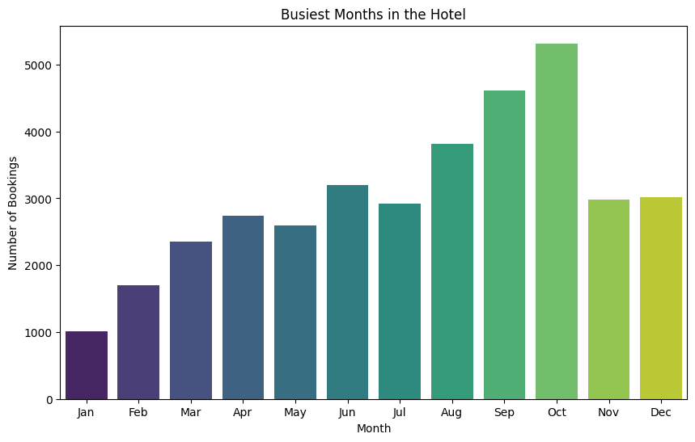

```python
def plot_months(data):
  busiest_months = data['The Arrival Month'].value_counts().sort_index()
  print('Bookings per month:\n', busiest_months)

  plt.figure(figsize=(10, 6))
  sns.barplot(x=busiest_months.index, y=busiest_months.values, palette='viridis')
  plt.title('Busiest Months in the Hotel')
  plt.xlabel('Month')
  plt.ylabel('Number of Bookings')
  plt.xticks(ticks=np.arange(12), labels=['Jan', 'Feb', 'Mar', 'Apr', 'May', 'Jun', 'Jul', 'Aug', 'Sep', 'Oct', 'Nov', 'Dec'])
  plt.show()
plot_months(data)
```

The busiest month is October.

```
Bookings per month:
 The Arrival Month
1       24
2      430
3      700
4      995
5      948
6     1291
7     1314
8     1488
9     1538
10    1880
11     875
12     402
Name: count, dtype: int64
```

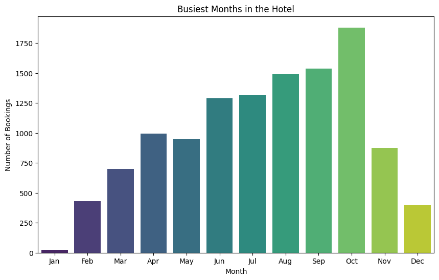

```python
plot_months(Bad)
```

```
Bookings per month:
 The Arrival Month
1      990
2     1274
3     1658
4     1741
5     1650
6     1912
7     1606
8     2325
9     3073
10    3437
11    2105
12    2619
Name: count, dtype: int64
```

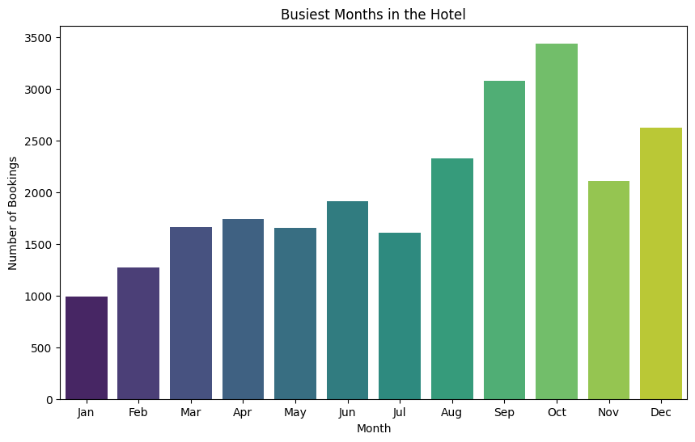

```python
plot_months(Good)
```

### Market Segment Density

```
Average Price per Market Segment:
 The Market Segment
Online           112.256855
Aviation         100.704000
Offline           91.632679
Corporate         82.911740
Complementary      3.141765
Name: Average Price #, dtype: float64
```

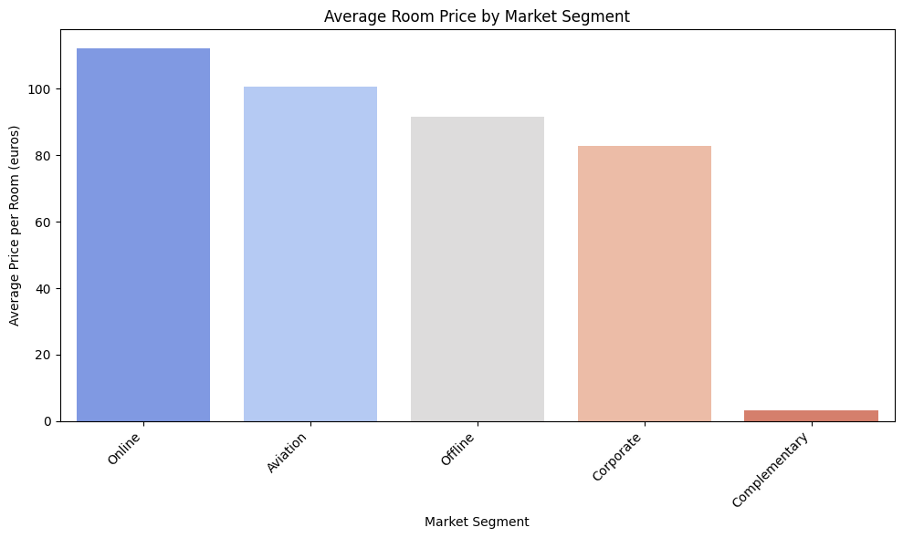

```python
avg_price_by_segment = data.groupby('The Market Segment')['Average Price #'].mean().sort_values(ascending=False)
print('\nAverage Price per Market Segment:\n', avg_price_by_segment)

plt.figure(figsize=(10, 6))
sns.barplot(x=avg_price_by_segment.index, y=avg_price_by_segment.values, palette='coolwarm')
plt.title('Average Room Price by Market Segment')
plt.xlabel('Market Segment')
plt.ylabel('Average Price per Room (euros)')
plt.xticks(rotation=45, ha='right')
plt.tight_layout()
plt.show()
```

```python
market_segmenter(data)
```

```
Market Segment Counts:
 The Market Segment
Online           23214
Offline          10528
Corporate         2017
Complementary      391
Aviation           125
Name: count, dtype: int64

The most common market segment is 'Online' with 23214 bookings.
```

```python
market_segmenter(Good)
```

```
Market Segment Counts:
 The Market Segment
Online           14739
Offline           7375
Corporate         1797
Complementary      391
Aviation            88
Name: count, dtype: int64

The most common market segment is 'Online' with 14739 bookings.
```

```python
market_segmenter(Bad)
```

```
Market Segment Counts:
 The Market Segment
Online       8475
Offline      3153
Corporate     220
Aviation       37
Name: count, dtype: int64

The most common market segment is 'Online' with 8475 bookings.
```

### Room Price by Market Segment

```
Average Price per Market Segment:
 The Market Segment
Online           112.256855
Aviation         100.704000
Offline           91.632679
Corporate         82.911740
Complementary      3.141765
Name: Average Price #, dtype: float64
```

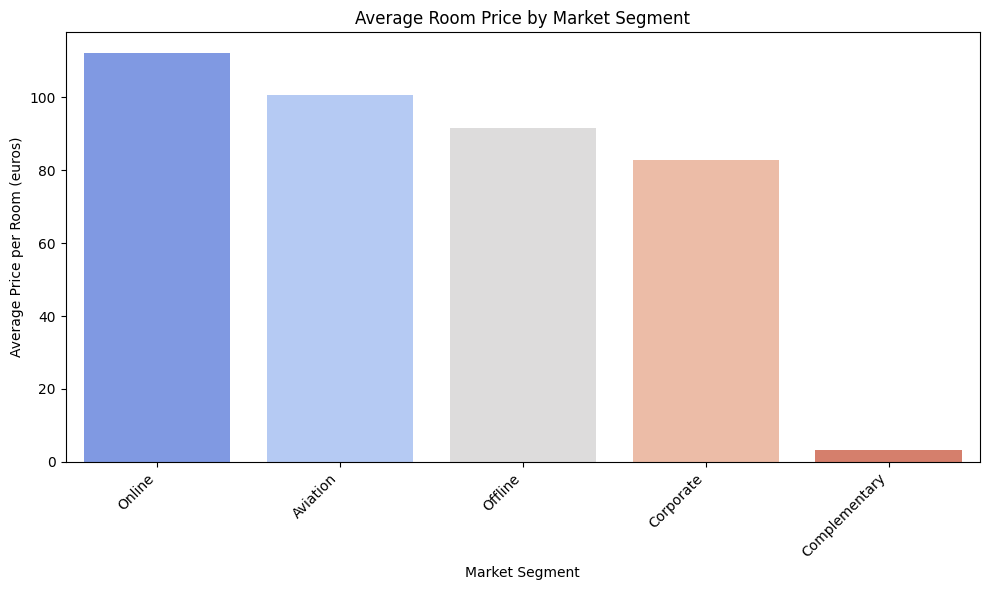

```python
def price_market(data):
    avg_price_by_segment = data.groupby('The Market Segment')['Average Price #'].mean().sort_values(ascending=False)
    print('\nAverage Price per Market Segment:\n', avg_price_by_segment)

    plt.figure(figsize=(10, 6))
    sns.barplot(x=avg_price_by_segment.index, y=avg_price_by_segment.values, palette='coolwarm')
    plt.title('Average Room Price by Market Segment')
    plt.xlabel('Market Segment')
    plt.ylabel('Average Price per Room (euros)')
    plt.xticks(rotation=45, ha='right')
    plt.tight_layout()
    plt.show()
price_market(data)
```

```
Average Price per Market Segment:
 The Market Segment
Online           110.888958
Aviation         100.056818
Offline           87.685201
Corporate         81.370612
Complementary      3.141765
Name: Average Price #, dtype: float64
```

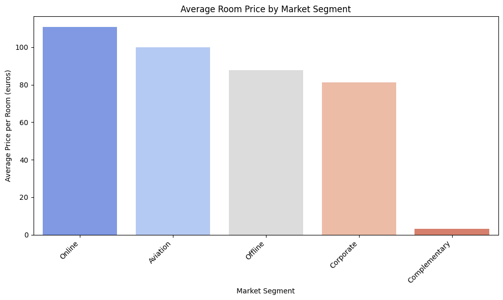

```python
price_market(Good)
```

```
Average Price per Market Segment:
 The Market Segment
Online       114.635785
Aviation     102.243243
Offline      100.865994
Corporate     95.499955
Name: Average Price #, dtype: float64
```

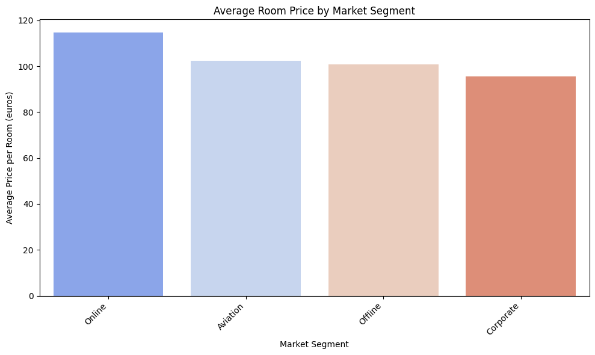

```python
price_market(Bad)
```

The corporate market tends to be more likely to cancel the more highly priced rooms.

### Percentage of Canceled Bookings

```python
cancellation_counts = data['The Booking Status'].value_counts()
total_bookings = cancellation_counts.sum()
canceled_bookings = cancellation_counts.get('Canceled', 0)

cancellation_percentage = (canceled_bookings / total_bookings) * 100

print(f"Total Bookings: {total_bookings}")
print(f"Canceled Bookings: {canceled_bookings}")
print(f"Not Canceled Bookings: {cancellation_counts.get('Not_Canceled', 0)}")
print(f"Percentage of Canceled Bookings: {cancellation_percentage:.2f}%")
```

```
Total Bookings: 36275
Canceled Bookings: 11885
Not Canceled Bookings: 24390
Percentage of Canceled Bookings: 32.76%
```

```python
repeated_guests_data = data[data['Repeated Guest?'] == 1]

repeated_guest_cancellation_counts = repeated_guests_data['The Booking Status'].value_counts()

total_repeated_guest_bookings = repeated_guest_cancellation_counts.sum()
canceled_repeated_guest_bookings = repeated_guest_cancellation_counts.get('Canceled', 0)

if total_repeated_guest_bookings > 0:
    percentage_canceled_repeated_guests = (canceled_repeated_guest_bookings / total_repeated_guest_bookings) * 100
    print(f"Total bookings by repeated guests: {total_repeated_guest_bookings}")
    print(f"Canceled bookings by repeated guests: {canceled_repeated_guest_bookings}")
    print(f"Percentage of canceled bookings by repeated guests: {percentage_canceled_repeated_guests:.2f}%")
else:
    print("No bookings found for repeated guests.")
```

```
Total bookings by repeated guests: 930
Canceled bookings by repeated guests: 16
Percentage of canceled bookings by repeated guests: 1.72%
```

### Special Requests

```
Cancellation rates based on number of special requests:
```

| The Booking Status Special Requests # | Canceled | Not_Canceled | Total | Cancellation_Percentage |
| --- | --- | --- | --- | --- |
| 0 | 8545 | 11232 | 19777 | 43.206755 |
| 1 | 2703 | 8670 | 11373 | 23.766816 |
| 2 | 637 | 3727 | 4364 | 14.596700 |
| 3 | 0 | 675 | 675 | 0.000000 |
| 4 | 0 | 78 | 78 | 0.000000 |
| 5 | 0 | 8 | 8 | 0.000000 |

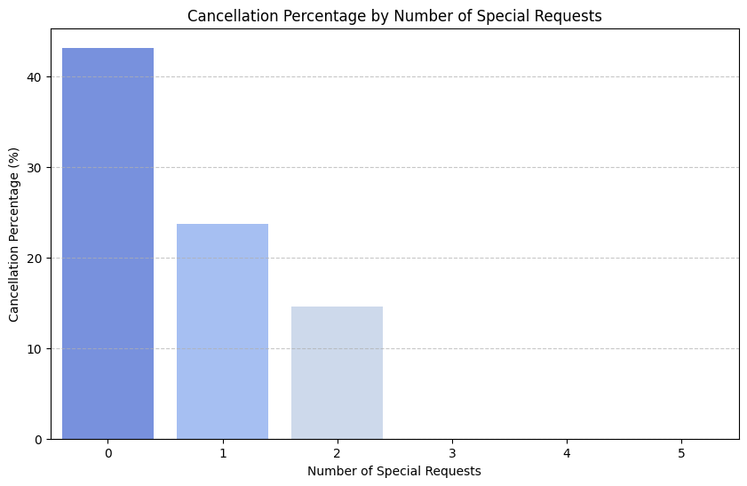

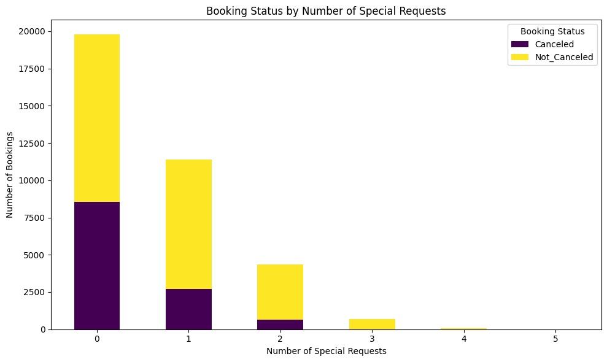

```python
# Grouping by 'Special Requests #' and 'The Booking Status' to count occurrences
special_requests_cancellation = data.groupby(['Special Requests #', 'The Booking Status']).size().unstack(fill_value=0)

# Cancellation percentage for each number of special requests
special_requests_cancellation['Total'] = special_requests_cancellation['Canceled'] + special_requests_cancellation['Not_Canceled']
special_requests_cancellation['Cancellation_Percentage'] = (special_requests_cancellation['Canceled'] / special_requests_cancellation['Total']) * 100

print("Cancellation rates based on number of special requests:\n")
display(special_requests_cancellation)

# The cancellation percentage
plt.figure(figsize=(10, 6))
sns.barplot(x=special_requests_cancellation.index, y=special_requests_cancellation['Cancellation_Percentage'], palette='coolwarm')
plt.title('Cancellation Percentage by Number of Special Requests')
plt.xlabel('Number of Special Requests')
plt.ylabel('Cancellation Percentage (%)')
plt.grid(axis='y', linestyle='--', alpha=0.7)
plt.show()

# The count of Canceled vs Not_Canceled for each special request category
special_requests_cancellation[['Canceled', 'Not_Canceled']].plot(kind='bar', stacked=True, figsize=(10, 6), colormap='viridis')
plt.title('Booking Status by Number of Special Requests')
plt.xlabel('Number of Special Requests')
plt.ylabel('Number of Bookings')
plt.xticks(rotation=0)
plt.legend(title='Booking Status')
plt.tight_layout()
plt.show()
```

## Bivariate Analysis - At A Glance

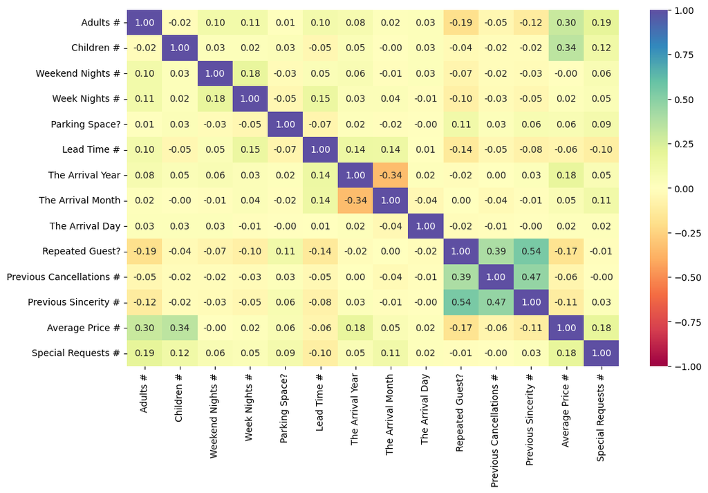

```python
cols_list = data.select_dtypes(include=np.number).columns.tolist()

plt.figure(figsize=(12, 7))
sns.heatmap(
    data[cols_list].corr(), annot=True, vmin=-1, vmax=1, fmt=".2f", cmap="Spectral"
)
plt.show()
```

**Observations**

- Guests who recieve lower prices are more likely to be returning guests.
- Guests are more likely to cancel reservations made with a greater lead time, a smaller number of special requests and on weekend nights.

## Data Preprocessing

- Missing value treatment (if needed)
- Feature engineering (if needed)
- Outlier detection and treatment (if needed)
- Preparing data for modeling
- Any other preprocessing steps (if needed)

But first, I will add a column of dates.

```python
TimedData = data.copy()
TimedData['Arrival Period'] = pd.to_datetime(TimedData[['The Arrival Year', 'The Arrival Month']].assign(day=15).rename(columns={'The Arrival Year': 'year', 'The Arrival Month': 'month'}))
display(TimedData.head())
```

|  | Adults # | Children # | Weekend Nights # | Week Nights # | The Meal Plan | Parking Space? | The Room Type | Lead Time # | The Arrival Year | The Arrival Month | The Arrival Day | The Market Segment | Repeated Guest? | Previous Cancellations # | Previous Sincerity # | Average Price # | Special Requests # | The Booking Status | Arrival Period |
| --- | --- | --- | --- | --- | --- | --- | --- | --- | --- | --- | --- | --- | --- | --- | --- | --- | --- | --- | --- |
| 0 | 2 | 0 | 1 | 2 | Meal Plan 1 | 0 | Room_Type 1 | 224 | 2017 | 10 | 2 | Offline | 0 | 0 | 0 | 65.00 | 0 | Not_Canceled | 2017-10-15 |
| 1 | 2 | 0 | 2 | 3 | Not Selected | 0 | Room_Type 1 | 5 | 2018 | 11 | 6 | Online | 0 | 0 | 0 | 106.68 | 1 | Not_Canceled | 2018-11-15 |
| 2 | 1 | 0 | 2 | 1 | Meal Plan 1 | 0 | Room_Type 1 | 1 | 2018 | 2 | 28 | Online | 0 | 0 | 0 | 60.00 | 0 | Canceled | 2018-02-15 |
| 3 | 2 | 0 | 0 | 2 | Meal Plan 1 | 0 | Room_Type 1 | 211 | 2018 | 5 | 20 | Online | 0 | 0 | 0 | 100.00 | 0 | Canceled | 2018-05-15 |
| 4 | 2 | 0 | 1 | 1 | Not Selected | 0 | Room_Type 1 | 48 | 2018 | 4 | 11 | Online | 0 | 0 | 0 | 94.50 | 0 | Canceled | 2018-04-15 |

Now, to check for outliers.

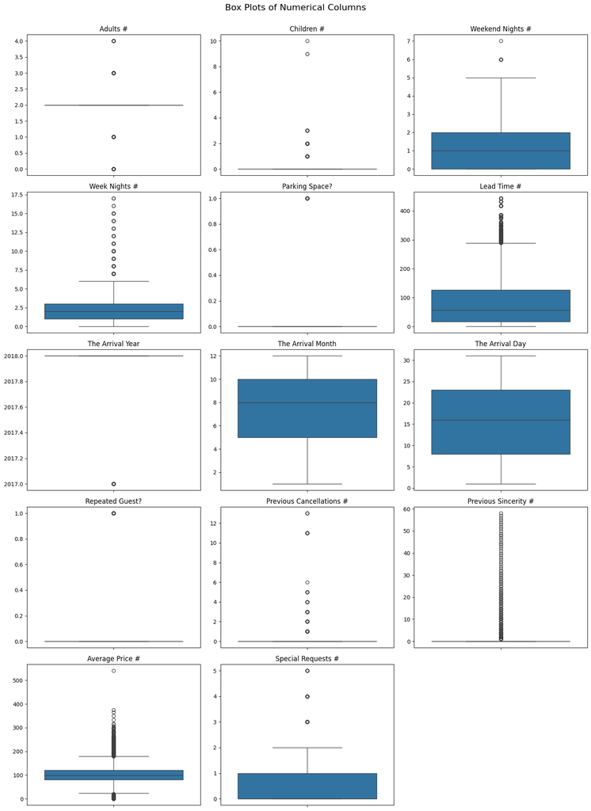

```python
numerical_cols = data.select_dtypes(include=np.number).columns.tolist()

# Exclude ID if it's considered purely an identifier and not a numerical feature for distribution analysis
if 'ID' in numerical_cols:
   numerical_cols.remove('ID')

# Determine grid size
num_plots = len(numerical_cols)
if num_plots == 0:
    print("No numerical columns found to plot.")
else:
    # Adjust figsize and grid layout based on the number of plots
    n_cols = 3 # Number of columns for subplots
    n_rows = (num_plots + n_cols - 1) // n_cols # Calculate number of rows needed

    fig, axes = plt.subplots(n_rows, n_cols, figsize=(n_cols * 5, n_rows * 4))
    axes = axes.flatten() # Flatten the 2D array of axes for easy iteration

    for i, col in enumerate(numerical_cols):
        sns.boxplot(y=data[col], ax=axes[i])
        axes[i].set_title(col)
        axes[i].set_ylabel('') # Remove y-label to avoid clutter

    # Hide any unused subplots
    for j in range(i + 1, len(axes)):
        fig.delaxes(axes[j])

    plt.tight_layout()
    plt.suptitle('Box Plots of Numerical Columns', y=1.02, fontsize=16)
    plt.show
```

While there are a great number of outliers; however, what the data represents is true; therefore, I will not treat them.

Now, I will split the data into train and test data so that I can both create a model and evaluate that model.

```python
X = data.drop(["The Booking Status"], axis=1)
Y = data["The Booking Status"].map({'Canceled': 1, 'Not_Canceled': 0})

# adding constant
X = sm.add_constant(X)

X = pd.get_dummies(X, drop_first=True)

# Splitting data in train and test sets
X_train, X_test, y_train, y_test = train_test_split(
    X, Y, test_size=0.30, random_state=1
)

X_train,X_test = X_train.astype('float'),X_test.astype('float')

print("Shape of Training set : ", X_train.shape)
print("Shape of test set : ", X_test.shape)
print("Percentage of classes in training set:")
print(y_train.value_counts(normalize=True))
print("Percentage of classes in test set:")
print(y_test.value_counts(normalize=True))
```

```
Shape of Training set :  (25392, 28)
Shape of test set :  (10883, 28)
Percentage of classes in training set:
The Booking Status
0    0.670644
1    0.329356
Name: proportion, dtype: float64
Percentage of classes in test set:
The Booking Status
0    0.676376
1    0.323624
Name: proportion, dtype: float64
```

The code ran as expected, and now, I can build the logistic regression model.

```python
logit = sm.Logit(y_train, X_train.astype(float))
lg = logit.fit(disp=False)

print(lg.summary())
```

```
                           Logit Regression Results
==============================================================================
Dep. Variable:     The Booking Status   No. Observations:                25392
Model:                          Logit   Df Residuals:                    25364
Method:                           MLE   Df Model:                           27
Date:                Fri, 03 Apr 2026   Pseudo R-squ.:                  0.3293
Time:                        21:14:02   Log-Likelihood:                -10793.
converged:                      False   LL-Null:                       -16091.
Covariance Type:            nonrobust   LLR p-value:                     0.000
====================================================================================================
                                       coef    std err          z      P>|z|      [0.025      0.975]
----------------------------------------------------------------------------------------------------
const                             -924.5923    120.817     -7.653      0.000   -1161.390    -687.795
Adults #                             0.1135      0.038      3.017      0.003       0.040       0.187
Children #                           0.1563      0.057      2.732      0.006       0.044       0.268
Weekend Nights #                     0.1068      0.020      5.398      0.000       0.068       0.146
Week Nights #                        0.0398      0.012      3.239      0.001       0.016       0.064
Parking Space?                      -1.5939      0.138    -11.561      0.000      -1.864      -1.324
Lead Time #                          0.0157      0.000     58.868      0.000       0.015       0.016
The Arrival Year                     0.4570      0.060      7.633      0.000       0.340       0.574
The Arrival Month                   -0.0415      0.006     -6.418      0.000      -0.054      -0.029
The Arrival Day                      0.0005      0.002      0.252      0.801      -0.003       0.004
Repeated Guest?                     -2.3469      0.617     -3.805      0.000      -3.556      -1.138
Previous Cancellations #             0.2664      0.086      3.108      0.002       0.098       0.434
Previous Sincerity #                -0.1727      0.153     -1.131      0.258      -0.472       0.127
Average Price #                      0.0188      0.001     25.404      0.000       0.017       0.020
Special Requests #                  -1.4690      0.030    -48.790      0.000      -1.528      -1.410
The Meal Plan_Meal Plan 2            0.1768      0.067      2.654      0.008       0.046       0.307
The Meal Plan_Meal Plan 3           17.8379   5057.771      0.004      0.997   -9895.212    9930.888
The Meal Plan_Not Selected           0.2782      0.053      5.245      0.000       0.174       0.382
The Room Type_Room_Type 2           -0.3610      0.131     -2.761      0.006      -0.617      -0.105
The Room Type_Room_Type 3           -0.0009      1.310     -0.001      0.999      -2.569       2.567
The Room Type_Room_Type 4           -0.2821      0.053     -5.305      0.000      -0.386      -0.178
The Room Type_Room_Type 5           -0.7176      0.209     -3.432      0.001      -1.127      -0.308
The Room Type_Room_Type 6           -0.9456      0.147     -6.434      0.000      -1.234      -0.658
The Room Type_Room_Type 7           -1.3964      0.293     -4.767      0.000      -1.971      -0.822
The Market Segment_Complementary   -41.8798   8.42e+05  -4.98e-05      1.000   -1.65e+06    1.65e+06
The Market Segment_Corporate        -1.1935      0.266     -4.487      0.000      -1.715      -0.672
The Market Segment_Offline          -2.1955      0.255     -8.625      0.000      -2.694      -1.697
The Market Segment_Online           -0.3990      0.251     -1.588      0.112      -0.891       0.093
====================================================================================================
```

**Observations**

- People are less likely to cancel if they require a parking space, have booked in the past, have a great number of special requests, and/or are booked offline or by a corporation.

## Multicollinearity

```python
vif = pd.DataFrame()
vif["feature"] = X_train.columns
vif["VIF"] = [
    variance_inflation_factor(X_train.values, i)
    for i in range(len(X_train.columns))
    ]
```

## Dropping The Insignificant

The following loop will go about creating a model, dropping the feature with the highest p-value, then repeating the process until there are no features with a p-value greater than 0.05

```python
# initial list of columns
cols = X_train.columns.tolist()

# setting an initial max p-value
max_p_value = 1

while len(cols) > 0:
    # defining the train set
    x_train_aux = X_train[cols]

    # fitting the model
    model = sm.Logit(y_train, x_train_aux).fit(disp=False)

    # getting the p-values and the maximum p-value
    p_values = model.pvalues
    max_p_value = max(p_values)

    # name of the variable with maximum p-value
    feature_with_p_max = p_values.idxmax()

    if max_p_value > 0.05:
        cols.remove(feature_with_p_max)
    else:
        break

selected_features = cols
print(selected_features)
```

[output not shown]

```python
X_train1 = X_train[selected_features]
X_test1 = X_test[selected_features]
logit1 = sm.Logit(y_train, X_train1.astype(float))
lg1 = logit1.fit(disp=False)
print(lg1.summary())
```

```
                           Logit Regression Results
==============================================================================
Dep. Variable:     The Booking Status   No. Observations:                25392
Model:                          Logit   Df Residuals:                    25370
Method:                           MLE   Df Model:                           21
Date:                Fri, 03 Apr 2026   Pseudo R-squ.:                  0.3283
Time:                        21:14:11   Log-Likelihood:                -10809.
converged:                       True   LL-Null:                       -16091.
Covariance Type:            nonrobust   LLR p-value:                     0.000
================================================================================================
                                   coef    std err          z      P>|z|      [0.025      0.975]
------------------------------------------------------------------------------------------------
const                         -917.2860    120.456     -7.615      0.000   -1153.376    -681.196
Adults #                         0.1086      0.037      2.914      0.004       0.036       0.182
Children #                       0.1522      0.057      2.660      0.008       0.040       0.264
Weekend Nights #                 0.1086      0.020      5.501      0.000       0.070       0.147
Week Nights #                    0.0418      0.012      3.403      0.001       0.018       0.066
Parking Space?                  -1.5943      0.138    -11.561      0.000      -1.865      -1.324
Lead Time #                      0.0157      0.000     59.218      0.000       0.015       0.016
The Arrival Year                 0.4531      0.060      7.591      0.000       0.336       0.570
The Arrival Month               -0.0424      0.006     -6.568      0.000      -0.055      -0.030
Repeated Guest?                 -2.7365      0.557     -4.915      0.000      -3.828      -1.645
Previous Cancellations #         0.2289      0.077      2.983      0.003       0.078       0.379
Average Price #                  0.0192      0.001     26.343      0.000       0.018       0.021
Special Requests #              -1.4699      0.030    -48.892      0.000      -1.529      -1.411
The Meal Plan_Meal Plan 2        0.1654      0.067      2.487      0.013       0.035       0.296
The Meal Plan_Not Selected       0.2858      0.053      5.405      0.000       0.182       0.389
The Room Type_Room_Type 2       -0.3560      0.131     -2.725      0.006      -0.612      -0.100
The Room Type_Room_Type 4       -0.2826      0.053     -5.330      0.000      -0.387      -0.179
The Room Type_Room_Type 5       -0.7352      0.208     -3.529      0.000      -1.143      -0.327
The Room Type_Room_Type 6       -0.9650      0.147     -6.572      0.000      -1.253      -0.677
The Room Type_Room_Type 7       -1.4312      0.293     -4.892      0.000      -2.005      -0.858
The Market Segment_Corporate    -0.7928      0.103     -7.711      0.000      -0.994      -0.591
The Market Segment_Offline      -1.7867      0.052    -34.391      0.000      -1.889      -1.685
================================================================================================
```

## Model Evaluation

Assuming that it is just as important to avoid underbooking as well as overbooking, the optimal strategy is to find the maximum F1 score.

```python
performance_checker(0.5)
```

```
Training performance:
```

|  | Accuracy | Recall | Precision | F1 |
| --- | --- | --- | --- | --- |
| 0 | 0.805411 | 0.632548 | 0.739033 | 0.681657 |

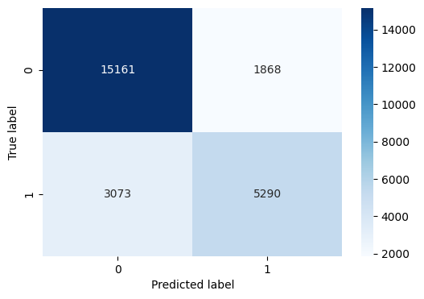

```python
heatmapper(0.5)
```

## ROC-AUC

The ROC-AUC graph stands for the Receiver Operating Characteristic's Area Under the Curve. In short, it shows how sensative the data becomes (how likely true positives are) when the likelihood of a false positive becomes greater.

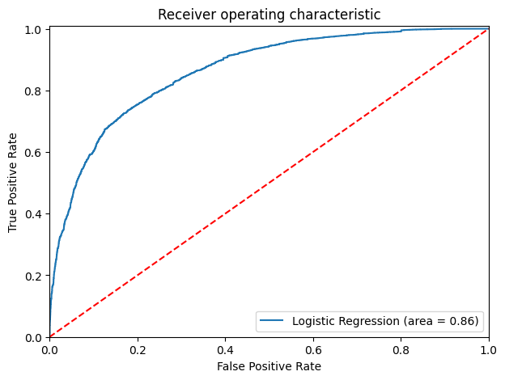

```python
logit_roc_auc_train = roc_auc_score(y_train, lg1.predict(X_train1))
fpr, tpr, thresholds = roc_curve(y_train, lg1.predict(X_train1))
plt.figure(figsize=(7, 5))
plt.plot(fpr, tpr, label="Logistic Regression (area = %0.2f)" % logit_roc_auc_train)
plt.plot([0, 1], [0, 1], "r--")
plt.xlim([0.0, 1.0])
plt.ylim([0.0, 1.01])
plt.xlabel("False Positive Rate")
plt.ylabel("True Positive Rate")
plt.title("Receiver operating characteristic")
plt.legend(loc="lower right")
plt.show()
```

An ROC-AUC score of 0.86 is pretty good, but let's see if the curve can be used to improve the model.

```python
# The optimal cut off would be where tpr is high and fpr is low
fpr, tpr, thresholds = roc_curve(y_train, lg1.predict(X_train1))

optimal_idx = np.argmax(tpr - fpr)
optimal_threshold_auc_roc = thresholds[optimal_idx]
print(optimal_threshold_auc_roc)
```

```
0.3710466623488775
```

```python
performance_checker(optimal_threshold_auc_roc)
```

```
Training performance:
```

|  | Accuracy | Recall | Precision | F1 |
| --- | --- | --- | --- | --- |
| 0 | 0.792888 | 0.735621 | 0.668696 | 0.700564 |

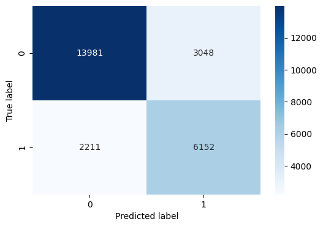

```python
heatmapper(optimal_threshold_auc_roc)
```

Perhaps the Precision-Recall curve will produce a better threshold.

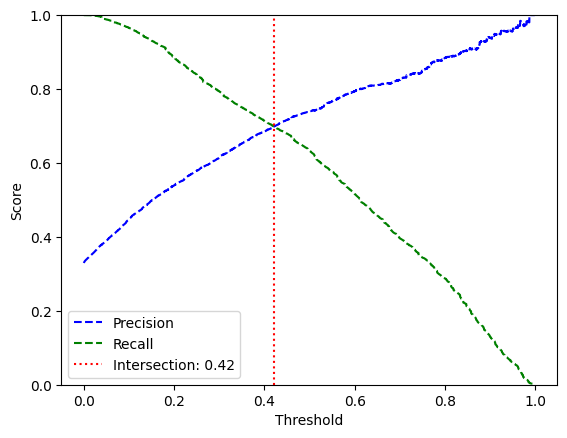

```
The approximate intersection point (threshold) for Precision and Recall is: 0.4210
```

```python
y_scores = lg1.predict(X_train1)
prec, rec, tre = precision_recall_curve(y_train, y_scores,)

plt.plot(tre, prec[:-1], "b--", label="Precision")
plt.plot(tre, rec[:-1], "g--", label="Recall")
plt.xlabel("Threshold")
plt.ylabel("Score")
plt.legend(loc="upper left")
plt.ylim([0, 1])

# Calculate the intersection point
# Find the threshold where precision and recall are closest
optimal_idx_pr = np.argmin(np.abs(prec[:-1] - rec[:-1]))
optimal_threshold_pr = tre[optimal_idx_pr]

plt.axvline(optimal_threshold_pr, color='r', linestyle=':', label=f'Intersection: {optimal_threshold_pr:.2f}')
plt.legend(loc="lower left")

plt.figure(figsize=(10, 7))
plt.show()

print(f"The approximate intersection point (threshold) for Precision and Recall is: {optimal_threshold_pr:.4f}")
```

```python
performance_checker(0.42)
```

```
Training performance:
```

|  | Accuracy | Recall | Precision | F1 |
| --- | --- | --- | --- | --- |
| 0 | 0.801276 | 0.69939 | 0.697888 | 0.698638 |

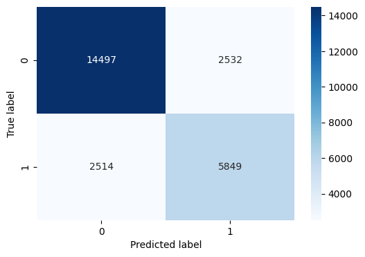

```python
heatmapper(0.42)
```

The F1 score is not greater than 0.7, and the heatmap isn't looking much better than before, so I will use the decision tree produced by setting to the threashold determined by the AUC-ROC.

## Building a Decision Tree model

```python
# Initialize the Decision Tree Classifier
dt_model = DecisionTreeClassifier(random_state=1)

# Fit the model to the training data
dt_model.fit(X_train, y_train)
```

```
DecisionTreeClassifier(random_state=1)
```

```
--- Decision Tree Model Evaluation ---
Accuracy: 0.8743
Precision (Canceled): 0.8008
Recall (Canceled): 0.8140
F1-Score (Canceled): 0.8074

Confusion Matrix:
```

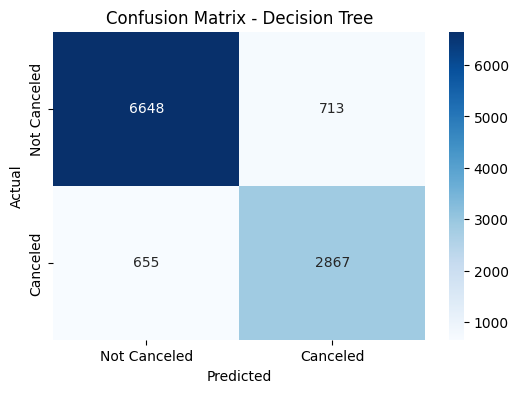

```python
# Make predictions on the test set
y_pred_dt = dt_model.predict(X_test)

# Evaluate model performance
print("\n--- Decision Tree Model Evaluation ---")
print(f"Accuracy: {accuracy_score(y_test, y_pred_dt):.4f}")
print(f"Precision (Canceled): {precision_score(y_test, y_pred_dt, pos_label=1):.4f}")
print(f"Recall (Canceled): {recall_score(y_test, y_pred_dt, pos_label=1):.4f}")
print(f"F1-Score (Canceled): {f1_score(y_test, y_pred_dt, pos_label=1):.4f}")

print("\nConfusion Matrix:")
cm = confusion_matrix(y_test, y_pred_dt)
plt.figure(figsize=(6, 4))
sns.heatmap(cm, annot=True, fmt='d', cmap='Blues', xticklabels=['Not Canceled', 'Canceled'], yticklabels=['Not Canceled', 'Canceled'])
plt.xlabel('Predicted')
plt.ylabel('Actual')
plt.title('Confusion Matrix - Decision Tree')
plt.show()
```

The decision tree seems to be overfitting the data. To begin considering how to prune the tree, I'll evaluate the importance of its features:

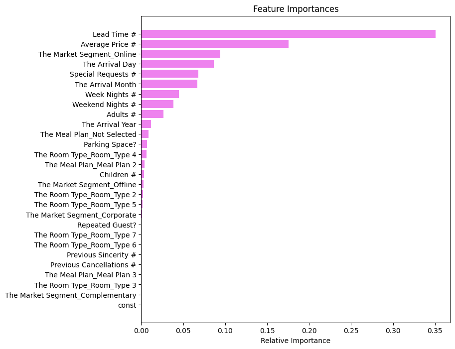

```python
feature_names = dt_model.feature_names_in_.tolist()
importances = dt_model.feature_importances_
indices = np.argsort(importances)

plt.figure(figsize=(8, 8))
plt.title("Feature Importances")
plt.barh(range(len(indices)), importances[indices], color="violet", align="center")
plt.yticks(range(len(indices)), [feature_names[i] for i in indices])
plt.xlabel("Relative Importance")
plt.show()
```

```python
# 1. Define the hyperparameter grid
param_grid = {
    'criterion': ['gini', 'entropy'],
    'max_depth': [5, 10, 15, None], # None means unlimited depth
    'min_samples_split': [2, 5, 10],
    'min_samples_leaf': [1, 5, 10]
}

# 2. Create a custom scorer for precision, focusing on the 'Canceled' class
# Assuming 1 represents 'Canceled' based on previous processing (data['The Booking Status'] = ... if x == 'Canceled' else 0)
precision_scorer = make_scorer(precision_score, pos_label=1, average='binary')

# 3. Initialize GridSearchCV
# dt_model was initialized in a previous cell as DecisionTreeClassifier(random_state=1)
grid_search = GridSearchCV(
    estimator=dt_model,
    param_grid=param_grid,
    scoring=precision_scorer, # Use the custom precision scorer
    cv=5,
    n_jobs=-1, # Use all available processors
    verbose=2
)

# 4. Fit GridSearchCV to the training data
grid_search.fit(X_train, y_train)

# 5. Print the best parameters and best score
print("Best Parameters found by GridSearchCV:", grid_search.best_params_)
print("Best Score (Precision for Canceled class) found by GridSearchCV:", grid_search.best_score_)
```

```
Fitting 5 folds for each of 72 candidates, totalling 360 fits
Best Parameters found by GridSearchCV: {'criterion': 'gini', 'max_depth': 15, 'min_samples_leaf': 10, 'min_samples_split': 2}
Best Score (Precision for Canceled class) found by GridSearchCV: 0.8205431507749369
```

## Train Tuned Decision Tree Model

A new Decision Tree classifier using the best hyperparameters found during the tuning process.

```python
from sklearn.tree import DecisionTreeClassifier

# Access the best parameters
best_params = grid_search.best_params_

# Initialize a new DecisionTreeClassifier with the best parameters
tuned_dt_model = DecisionTreeClassifier(random_state=1, **best_params)

# Fit the tuned model to the training data
tuned_dt_model.fit(X_train, y_train)

print("Tuned Decision Tree model trained successfully with best parameters:")
print(best_params)
```

```
Tuned Decision Tree model trained successfully with best parameters:
{'criterion': 'gini', 'max_depth': 15, 'min_samples_leaf': 10, 'min_samples_split': 2}
```

Now that the tuned Decision Tree model is trained, the next step is to evaluate its performance on the test set to determine how well it generalizes and to compare it with the untuned model. This involves calculating common classification metrics and visualizing the confusion matrix.

```
--- Tuned Decision Tree Model Evaluation ---
Accuracy: 0.8717
Precision (Canceled): 0.8204
Recall (Canceled): 0.7729
F1-Score (Canceled): 0.7959

Confusion Matrix:
```

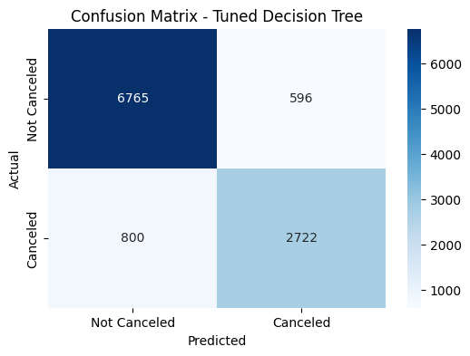

```
Classification Report:
              precision    recall  f1-score   support

           0       0.89      0.92      0.91      7361
           1       0.82      0.77      0.80      3522

    accuracy                           0.87     10883
   macro avg       0.86      0.85      0.85     10883
weighted avg       0.87      0.87      0.87     10883
```

```python
# Make predictions on the test set using the tuned model
y_pred_tuned_dt = tuned_dt_model.predict(X_test)

# Evaluate model performance
print("\n--- Tuned Decision Tree Model Evaluation ---")
print(f"Accuracy: {accuracy_score(y_test, y_pred_tuned_dt):.4f}")
print(f"Precision (Canceled): {precision_score(y_test, y_pred_tuned_dt, pos_label=1):.4f}")
print(f"Recall (Canceled): {recall_score(y_test, y_pred_tuned_dt, pos_label=1):.4f}")
print(f"F1-Score (Canceled): {f1_score(y_test, y_pred_tuned_dt, pos_label=1):.4f}")

print("\nConfusion Matrix:")
cm_tuned = confusion_matrix(y_test, y_pred_tuned_dt)
plt.figure(figsize=(6, 4))
sns.heatmap(cm_tuned, annot=True, fmt='d', cmap='Blues', xticklabels=['Not Canceled', 'Canceled'], yticklabels=['Not Canceled', 'Canceled'])
plt.xlabel('Predicted')
plt.ylabel('Actual')
plt.title('Confusion Matrix - Tuned Decision Tree')
plt.show()

print("\nClassification Report:")
print(classification_report(y_test, y_pred_tuned_dt))
```

To compare the performance of the initial and tuned Decision Tree models, I will extract and store the key evaluation metrics (Accuracy, Precision, Recall, F1-Score for the 'Canceled' class) for both models from the previously generated predictions and then display them in a comparison table.

```python
# Metrics for Initial Decision Tree Model (from y_pred_dt)
initial_dt_metrics = {
    'Accuracy': accuracy_score(y_test, y_pred_dt),
    'Precision (Canceled)': precision_score(y_test, y_pred_dt, pos_label=1),
    'Recall (Canceled)': recall_score(y_test, y_pred_dt, pos_label=1),
    'F1-Score (Canceled)': f1_score(y_test, y_pred_dt, pos_label=1)
}

# Metrics for Tuned Decision Tree Model (from y_pred_tuned_dt)
tuned_dt_metrics = {
    'Accuracy': accuracy_score(y_test, y_pred_tuned_dt),
    'Precision (Canceled)': precision_score(y_test, y_pred_tuned_dt, pos_label=1),
    'Recall (Canceled)': recall_score(y_test, y_pred_tuned_dt, pos_label=1),
    'F1-Score (Canceled)': f1_score(y_test, y_pred_tuned_dt, pos_label=1)
}

# Create a DataFrame for comparison
comparison_df = pd.DataFrame({
    'Initial DT': initial_dt_metrics,
    'Tuned DT': tuned_dt_metrics
})

print("\n--- Model Performance Comparison ---")
display(comparison_df.round(4))
```

```
--- Model Performance Comparison ---
```

|  | Initial DT | Tuned DT |
| --- | --- | --- |
| Accuracy | 0.8743 | 0.8717 |
| Precision (Canceled) | 0.8008 | 0.8204 |
| Recall (Canceled) | 0.8140 | 0.7729 |
| F1-Score (Canceled) | 0.8074 | 0.7959 |

# The Best Decision Tree

```python
# Get feature names from X_train
feature_names = X_train.columns.tolist()

# Define class names
class_names = ['Not_Canceled', 'Canceled']

# Generate DOT data
dot_data = export_graphviz(
    tuned_dt_model,
    out_file=None,
    feature_names=feature_names,
    class_names=class_names,
    filled=True,
    rounded=True,
    special_characters=True,
    impurity=False
)

# Create a graphviz.Source object and render it
graph = graphviz.Source(dot_data)
graph
```

[figure not shown]

The decision tree above is interesting but hard to read. Below, I have included a written version of the tree for whatever programming applications the hotel may want to develop using the model.

```python
# Get feature names from X_train (ensure 'const' is removed if it's not a real feature)
# We'll use the feature_names that were already prepared for graphviz
feature_names = X_train.columns.tolist()

# Define class names
class_names = ['Not_Canceled', 'Canceled']

# Generate the textual representation of the decision tree
tree_rules = export_text(tuned_dt_model, feature_names=feature_names, class_names=class_names)

print("--- Textual Decision Tree Rules ---")
print(tree_rules)
```

```
--- Textual Decision Tree Rules ---
|--- Lead Time # <= 151.50
|   |--- Special Requests # <= 0.50
|   |   |--- The Market Segment_Online <= 0.50
|   |   |   |--- Lead Time # <= 90.50
|   |   |   |   |--- Average Price # <= 201.50
|   |   |   |   |   |--- Weekend Nights # <= 0.50
|   |   |   |   |   |   |--- The Market Segment_Offline <= 0.50
|   |   |   |   |   |   |   |--- Lead Time # <= 16.50
|   |   |   |   |   |   |   |   |--- The Room Type_Room_Type 4 <= 0.50
|   |   |   |   |   |   |   |   |   |--- Repeated Guest? <= 0.50
|   |   |   |   |   |   |   |   |   |   |--- Lead Time # <= 11.50
|   |   |   |   |   |   |   |   |   |   |   |--- truncated branch of depth 5
|   |   |   |   |   |   |   |   |   |   |--- Lead Time # >  11.50
|   |   |   |   |   |   |   |   |   |   |   |--- truncated branch of depth 2
|   |   |   |   |   |   |   |   |   |--- Repeated Guest? >  0.50
|   |   |   |   |   |   |   |   |   |   |--- class: Not_Canceled
|   |   |   |   |   |   |   |   |--- The Room Type_Room_Type 4 >  0.50
|   |   |   |   |   |   |   |   |   |--- Average Price # <= 83.00
|   |   |   |   |   |   |   |   |   |   |--- class: Not_Canceled
|   |   |   |   |   |   |   |   |   |--- Average Price # >  83.00
|   |   |   |   |   |   |   |   |   |   |--- Lead Time # <= 9.50
|   |   |   |   |   |   |   |   |   |   |   |--- truncated branch of depth 2
|   |   |   |   |   |   |   |   |   |   |--- Lead Time # >  9.50
|   |   |   |   |   |   |   |   |   |   |   |--- class: Canceled
|   |   |   |   |   |   |   |--- Lead Time # >  16.50
|   |   |   |   |   |   |   |   |--- The Arrival Month <= 5.50
|   |   |   |   |   |   |   |   |   |--- The Arrival Day <= 16.50
|   |   |   |   |   |   |   |   |   |   |--- class: Not_Canceled
|   |   |   |   |   |   |   |   |   |--- The Arrival Day >  16.50
|   |   |   |   |   |   |   |   |   |   |--- Adults # <= 1.50
|   |   |   |   |   |   |   |   |   |   |   |--- truncated branch of depth 2
|   |   |   |   |   |   |   |   |   |   |--- Adults # >  1.50
|   |   |   |   |   |   |   |   |   |   |   |--- class: Canceled
|   |   |   |   |   |   |   |   |--- The Arrival Month >  5.50
|   |   |   |   |   |   |   |   |   |--- Average Price # <= 97.50
|   |   |   |   |   |   |   |   |   |   |--- The Arrival Month <= 11.50
|   |   |   |   |   |   |   |   |   |   |   |--- truncated branch of depth 5
|   |   |   |   |   |   |   |   |   |   |--- The Arrival Month >  11.50
|   |   |   |   |   |   |   |   |   |   |   |--- class: Not_Canceled
```

[output cut: 970 more lines]

```
|   |   |   |   |   |   |--- class: Not_Canceled
|   |--- Average Price # >  100.04
|   |   |--- The Arrival Month <= 11.50
|   |   |   |--- Special Requests # <= 2.50
|   |   |   |   |--- class: Canceled
|   |   |   |--- Special Requests # >  2.50
|   |   |   |   |--- class: Not_Canceled
|   |   |--- The Arrival Month >  11.50
|   |   |   |--- Special Requests # <= 0.50
|   |   |   |   |--- class: Not_Canceled
|   |   |   |--- Special Requests # >  0.50
|   |   |   |   |--- The Arrival Day <= 26.50
|   |   |   |   |   |--- class: Not_Canceled
|   |   |   |   |--- The Arrival Day >  26.50
|   |   |   |   |   |--- class: Canceled
```

```
Top 10 Feature Importances:
Lead Time #                  0.402406
Average Price #              0.152217
The Market Segment_Online    0.133850
Special Requests #           0.097279
The Arrival Month            0.061445
The Arrival Day              0.037266
Weekend Nights #             0.031666
Adults #                     0.025267
Week Nights #                0.020720
The Arrival Year             0.014397
dtype: float64
```

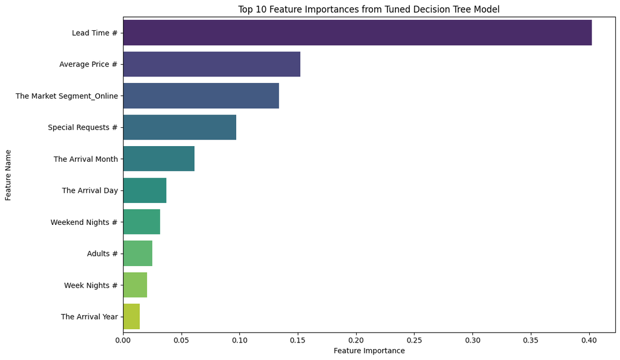

```python
# Access feature_importances_ attribute
feature_importances = tuned_dt_model.feature_importances_

# Create a Pandas Series using these importances, mapping them to the feature names from X_train.columns
# Ensure feature_names matches the order of features used in training
feature_names = X_train.columns.tolist()
importance_series = pd.Series(feature_importances, index=feature_names)

# Listing important features
sorted_importance = importance_series.sort_values(ascending=False)
print("Top 10 Feature Importances:")
print(sorted_importance.head(10))

# Create a bar plot to visualize the top features
plt.figure(figsize=(12, 7))
sns.barplot(x=sorted_importance.head(10).values, y=sorted_importance.head(10).index, palette='viridis')
plt.title('Top 10 Feature Importances from Tuned Decision Tree Model')
plt.xlabel('Feature Importance')
plt.ylabel('Feature Name')
plt.tight_layout()
plt.show()
```

## Actionable Insights and Recommendations

I also recommend that the hotel run each reservation through the decision tree model provided above in order to estimate the supply of rooms when determining the price that they should be sold for given some equation for determining demand.

```python
import time
time.sleep(120)
!jupyter nbconvert --to html '/content/drive/MyDrive/Data Analytics/Decision Tree/Decision Tree Project.ipynb' --output-dir '/content/drive/MyDrive/Data Analytics/Portfolio'
```